# Lab 4 - Building Linear Regression Models

Cameron Wonchoba

02/16/2020

# Overview

### Background

In this lab, we are given a dataset that describes a patients age, sex, bmi, blood pressure, and their blood. Using this information about many patients, we will try to create a model that predict the disease progression of diabetes.

### Problem

This is a classic regression problem, where we are trying to predict a continuous value.

### Methods

In this lab, we will be using Single Linear Regression and Multiple Linear Regression to find which method performs the best. Additionally, we will introduce some feature selection to see if we can get better results.

# Data

This dataset can be found [here](https://www4.stat.ncsu.edu/~boos/var.select/diabetes.tab.txt). The diabetes dataset has 10 features, age, sex, bmi, bp, s1, s2, s3, s4, s5, s6. Using these 10 features and 442 observations, the goal is to predict the response variable, Disease Progression (of diabetes).

```python
import matplotlib.pyplot as plt
import numpy as np
from sklearn import datasets, linear_model
from sklearn.metrics import mean_squared_error, r2_score
import pandas as pd
```

```python
# Load the diabetes dataset that is already scaled
diabetes = datasets.load_diabetes()
```

```python
df_features = pd.DataFrame(diabetes.data, columns=diabetes.feature_names)
df_target = pd.DataFrame(diabetes.target)
```

# Exploratory Data Analysis

```python
df_features.shape
```

```
(442, 10)
```

There are 442 observations and 10 features

```python
df_features.isnull().any()
```

```
age    False
sex    False
bmi    False
bp     False
s1     False
s2     False
s3     False
s4     False
s5     False
s6     False
dtype: bool
```

**None** of the columns have NaNs or Null values.

```python
df_features.describe()
```

|  | age | sex | bmi | bp | s1 | s2 | s3 | s4 | s5 | s6 |
| --- | --- | --- | --- | --- | --- | --- | --- | --- | --- | --- |
| count | 4.420000e+02 | 4.420000e+02 | 4.420000e+02 | 4.420000e+02 | 4.420000e+02 | 4.420000e+02 | 4.420000e+02 | 4.420000e+02 | 4.420000e+02 | 4.420000e+02 |
| mean | -3.634285e-16 | 1.308343e-16 | -8.045349e-16 | 1.281655e-16 | -8.835316e-17 | 1.327024e-16 | -4.574646e-16 | 3.777301e-16 | -3.830854e-16 | -3.412882e-16 |
| std | 4.761905e-02 | 4.761905e-02 | 4.761905e-02 | 4.761905e-02 | 4.761905e-02 | 4.761905e-02 | 4.761905e-02 | 4.761905e-02 | 4.761905e-02 | 4.761905e-02 |
| min | -1.072256e-01 | -4.464164e-02 | -9.027530e-02 | -1.123996e-01 | -1.267807e-01 | -1.156131e-01 | -1.023071e-01 | -7.639450e-02 | -1.260974e-01 | -1.377672e-01 |
| 25% | -3.729927e-02 | -4.464164e-02 | -3.422907e-02 | -3.665645e-02 | -3.424784e-02 | -3.035840e-02 | -3.511716e-02 | -3.949338e-02 | -3.324879e-02 | -3.317903e-02 |
| 50% | 5.383060e-03 | -4.464164e-02 | -7.283766e-03 | -5.670611e-03 | -4.320866e-03 | -3.819065e-03 | -6.584468e-03 | -2.592262e-03 | -1.947634e-03 | -1.077698e-03 |
| 75% | 3.807591e-02 | 5.068012e-02 | 3.124802e-02 | 3.564384e-02 | 2.835801e-02 | 2.984439e-02 | 2.931150e-02 | 3.430886e-02 | 3.243323e-02 | 2.791705e-02 |
| max | 1.107267e-01 | 5.068012e-02 | 1.705552e-01 | 1.320442e-01 | 1.539137e-01 | 1.987880e-01 | 1.811791e-01 | 1.852344e-01 | 1.335990e-01 | 1.356118e-01 |

## Histograms describing the target

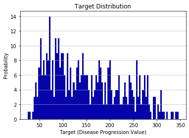

```python
n, bins, patches = plt.hist(x = diabetes.target, bins = 100, color = '#0504aa')
plt.grid(axis='y', alpha=0.75)
plt.xlabel('Target (Disease Progression Value)')
plt.ylabel('Probability')
plt.title('Target Distribution')
plt.show()
```

```
array([[<matplotlib.axes._subplots.AxesSubplot object at 0x0000017697394F88>]],
      dtype=object)
```

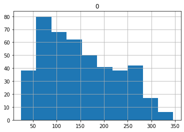

```python
# Another histogram that is simpler.
df_target.hist()
```

## Bounds of target

```python
print("MINIMUM: ", df_target.min())
print("MAXIMUM: ", df_target.max())
```

```
MINIMUM:  0    25.0
dtype: float64
MAXIMUM:  0    346.0
dtype: float64
```

The target variables are bounded between 25 and 346.

## Scatter Plot for every feature

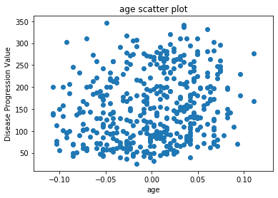

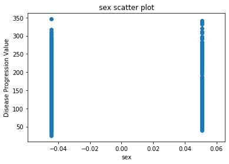

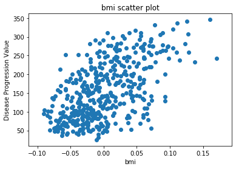

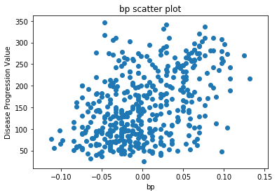

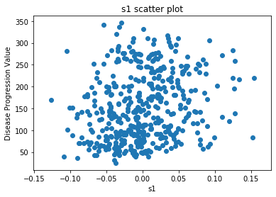

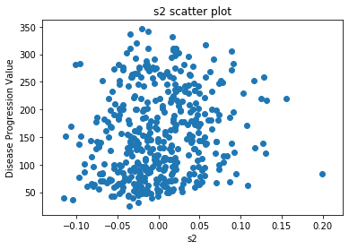

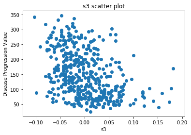

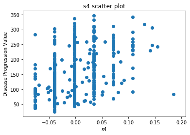

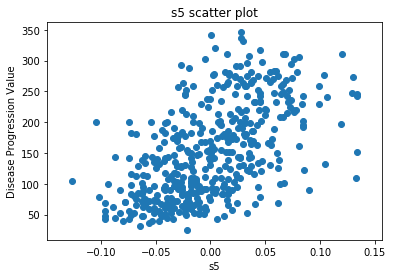

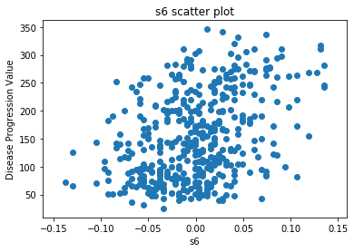

```python
for col in df_features.columns:
    plt.scatter(df_features[col], df_target)

    plt.xlabel(col)
    plt.ylabel('Disease Progression Value')
    plt.title(f'{col} scatter plot')
    plt.show()
```

### Age

Age seems to have no correlation with the Disease Progression Value.

### Sex

Sex seems to have no correlation with the Disease Progression Value.

### bmi

bmi seems to have a positive linearly relationship with Disease Progression Value. This relationship is subtle, but definitely there.

### bp

bp seems to have a positive lineraly relationship with Disease Progression Value. This relationship is more subtle than bmi (as there are more outliers), but it is still there.

### s1

s1 seems to have no correlation with Disease Progression Value.

### s2

s2 seems to have no correlation with Disease Progression Value.

### s3

s3 seems to have a negative exponential curve. As s3 gets larger, the Disease Progression Value rapidly decreases.

### s4

s4 seems to have no correlation with Disease Progression Value.

### s5

s5 seems to have a positive relationship with Disease Progression Value. However, it is hard to tell if that relationship is linear or exponential.

### s6

s6 seems to have a positive relationship with Disease Progression Value.

## Correlations between each feature. Detecting for the prescence of conlinearity

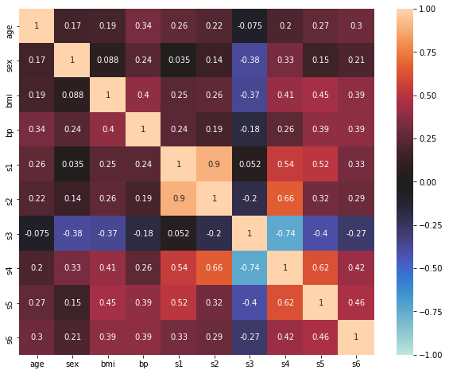

```python
import seaborn as sns
df = pd.DataFrame(diabetes.data, columns=diabetes.feature_names)
fig, ax = plt.subplots(figsize=(10,8))
corrmat = df.corr() # Omit year
sns.heatmap(corrmat,-1,1,ax=ax,center=0,annot=True);
```

### Highly Correlated Features

- s1 & s2 (0.9)
- s4 & s2 (0.66)
- s4 & s3 (-0.74)

### Colinearity

The correlation matrix is imporant beacuse linear regression models assume that features are independent of each other. We may want to do something to features that have higher correlation values (whether it is dropping one of the features, or some other feature engineering).

We will have have to do something about the colinearity seen above.

# Models

## Single Linear Regression - BMI

Below will be code that only tries to predict the Disease Progression Rate by only using BMI.

```python
import matplotlib.pyplot as plt
import numpy as np
from sklearn import datasets, linear_model
from sklearn.metrics import mean_squared_error, r2_score
```

```
Coefficients:
 [938.23786125]
Mean squared error: 2548.07
Root mean squared error: 50.48

Mean of diabetes target variable =  126.2
RMSE percentage of diabetes mean =  39.998759894526835
Coefficient of determination: 0.47
```

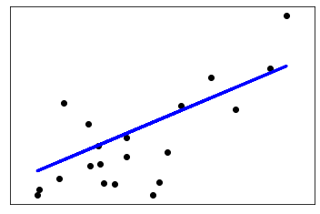

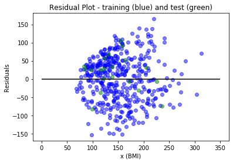

```python
# Load the diabetes dataset
diabetes_X, diabetes_y = datasets.load_diabetes(return_X_y=True)

# Use only bmi feature
diabetes_X = diabetes_X[:, np.newaxis, 2]

# Split the data into training/testing sets
diabetes_X_train = diabetes_X[:-20]
diabetes_X_test = diabetes_X[-20:]

# Split the targets into training/testing sets
diabetes_y_train = diabetes_y[:-20]
diabetes_y_test = diabetes_y[-20:]

# Create linear regression object
regr = linear_model.LinearRegression()

# Train the model using the training sets
regr.fit(diabetes_X_train, diabetes_y_train)

# Make predictions using the testing set
diabetes_y_pred = regr.predict(diabetes_X_test)

# The coefficients
print('Coefficients: \n', regr.coef_)
# The mean squared error
print('Mean squared error: %.2f'
      % mean_squared_error(diabetes_y_test, diabetes_y_pred))
# The coefficient of determination: 1 is perfect prediction
print("Root mean squared error: %.2f"
      % np.sqrt( mean_squared_error(diabetes_y_test, diabetes_y_pred)) )
print("\nMean of diabetes target variable = ",diabetes_y_test.mean())
print("RMSE percentage of diabetes mean = ", \
      100 * np.sqrt( mean_squared_error(diabetes_y_test, diabetes_y_pred))/diabetes_y_test.mean())
print('Coefficient of determination: %.2f'
      % r2_score(diabetes_y_test, diabetes_y_pred))

# Plot outputs
plt.scatter(diabetes_X_test, diabetes_y_test,  color='black')
plt.plot(diabetes_X_test, diabetes_y_pred, color='blue', linewidth=3)

plt.xticks(())
plt.yticks(())

plt.show()

# c = color
# alpha - blending value, between 0 (transparent) and 1 (opaque)
plt.scatter( regr.predict(diabetes_X_train), regr.predict(diabetes_X_train) - diabetes_y_train, c = 'b', alpha = '0.5')
plt.scatter( regr.predict(diabetes_X_test), regr.predict(diabetes_X_test) - diabetes_y_test, c = 'g', alpha = '0.5')
plt.hlines(y = 0, xmin = 0, xmax = 350)
plt.title('Residual Plot - training (blue) and test (green)')
plt.ylabel('Residuals')
plt.xlabel('x (BMI)')
```

#### Accuracy:

- MSE: 2548.07
- RMSE: 50.48 The closer these numbers are to 0, the better - sum of all errors should be small. We want our sum of residuals to be 0. The Residual Plot shows that it is not. In fact the Residual Plot shows that there are a bunch of problems and errors made with out model.
- r squared: 0.47 r squared tells us how much variance is explained by our model (1 is perfect, 0 is the worst). Our value of 0.47 shows that we have a lot of work to do.

#### Formula:

y = bmi*(938.23)

#### Accept or Reject?

Although this model has found some correlation between the BMI and Disease Progression Value, we didn't utilize any of the other data. We should **reject** this model because we can very likely do better.

## Multiple Linear Regression - All Features

Below will be code that tries to predict the Disease Progression Rate by using all of the features.

```
Coefficients:
 [ 3.03499549e-01 -2.37639315e+02  5.10530605e+02  3.27736980e+02
 -8.14131709e+02  4.92814588e+02  1.02848452e+02  1.84606489e+02
  7.43519617e+02  7.60951722e+01]
<class 'numpy.ndarray'>
  Columns  Coefficients
0     age      0.303500
1     sex   -237.639315
2     bmi    510.530605
3      bp    327.736980
4      s1   -814.131709
5      s2    492.814588
6      s3    102.848452
7      s4    184.606489
8      s5    743.519617
9      s6     76.095172
Mean squared error: 2004.57
Root mean squared error: 44.77

Mean of diabetes target variable =  126.2
RMSE percentage of diabetes mean =  35.47733579783276
Coefficient of determination: 0.59
```

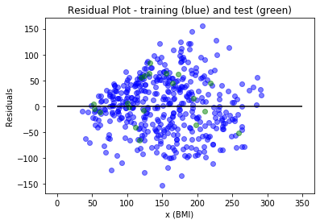

```python
import statsmodels.api as sm

diabetes_X = diabetes.data

# Split the data into training/testing sets
diabetes_X_train = diabetes_X[:-20]
diabetes_X_test = diabetes_X[-20:]

# Create linear regression object
lm = linear_model.LinearRegression()

# Train the model using the training sets
fit = lm.fit(diabetes_X_train, diabetes_y_train)

# Make predictions using the testing set
diabetes_y_pred = fit.predict(diabetes_X_test)

# The coefficients
print('Coefficients: \n', fit.coef_)
print ( type(fit.coef_))

# https://bigdata-madesimple.com/how-to-run-linear-regression-in-python-scikit-learn/
# get feature names
colnames = np.asarray(df.columns)

# https://pandas.pydata.org/pandas-docs/stable/user_guide/merging.html
df_col = pd.DataFrame( data = np.asarray(df.columns)  )
df_coef = pd.DataFrame( data = fit.coef_)
df_tbl =  pd.concat ( [df_col, df_coef] , axis = 1 )
df_tbl.columns = ['Columns', 'Coefficients']
print(df_tbl)

#  scipy.stats OLS linear regression model
X_train = sm.add_constant(diabetes_X_train)
lm2 = sm.OLS(diabetes_y_train, X_train).fit()
lm2.summary()

# The mean squared error
print("Mean squared error: %.2f"
      % mean_squared_error(diabetes_y_test, diabetes_y_pred))

print("Root mean squared error: %.2f"
      % np.sqrt( mean_squared_error(diabetes_y_test, diabetes_y_pred)) )

print("\nMean of diabetes target variable = ",diabetes_y_test.mean())

print("RMSE percentage of diabetes mean = ", \
      100 * np.sqrt( mean_squared_error(diabetes_y_test, diabetes_y_pred))/diabetes_y_test.mean())

print('Coefficient of determination: %.2f'
      % r2_score(diabetes_y_test, diabetes_y_pred))

# c = color
# alpha - blending value, between 0 (transparent) and 1 (opaque)
plt.scatter( lm.predict(diabetes_X_train), lm.predict(diabetes_X_train) - diabetes_y_train, c = 'b', alpha = '0.5')
plt.scatter( lm.predict(diabetes_X_test), lm.predict(diabetes_X_test) - diabetes_y_test, c = 'g', alpha = '0.5')
plt.hlines(y = 0, xmin = 0, xmax = 350)
plt.title('Residual Plot - training (blue) and test (green)')
plt.ylabel('Residuals')
plt.xlabel('x (BMI)')
```

#### Accuracy:

- MSE: 2004.57
- RMSE: 44.77 The closer these numbers are to 0, the better - sum of all errors should be small. We want our sum of residuals to be 0. The Residual Plot shows that it is not. In fact the Residual Plot shows that there are a bunch of problems and errors made with out model.

Although there are issues and errors within this model, this model performs better than the Single Linear Regression model that was built using BMI as the input variable.

- r squared: 0.59 r squared tells us how much variance is explained by our model (1 is perfect, 0 is the worst). Our value of 0.59 shows that we are getting to some sort of correlation. However, we still need to improve. Note: This is better than the Single Linear Regression model that was built using BMI as the input variable.

#### Formula:

y = age *0.303500 + sex* -237.639315 + bmi *510.530605 + bp* 327.736980 + s1 *-814.131709 + s2* 492.814588 + s3 *102.848452 + s4* 184.606489 + s5 *743.519617 + s6* 76.095172

#### Accept or Reject?

Although this model has found some correlation between the all of the features and Disease Progression Value, we kept highly correlated features and didn't implement any feature enigineering. We should **reject** this model because we can very likely do better.

## Multiple Linear Regression - Alternative Model

Below will be code that implements feature selection. After this is done, the new features will be used to predict the Disease Progression Rate.

```python
import matplotlib.pyplot as plt
import numpy as np
from sklearn import datasets, linear_model
from sklearn.metrics import mean_squared_error, r2_score
import pandas as pd
```

```python
# Load the diabetes dataset that is already scaled
diabetes = datasets.load_diabetes()
```

```python
df_features = pd.DataFrame(diabetes.data, columns=diabetes.feature_names)
df_target = pd.DataFrame(diabetes.target)
df_features.columns
```

```
Index(['age', 'sex', 'bmi', 'bp', 's1', 's2', 's3', 's4', 's5', 's6'], dtype='object')
```

## Randomized Feature Selection

Select random features 10,000 times and track the best **RMSE** and the features that correspond to that RMSE score.

##### Why?

In class, you discuss forward selection and backward selection, but this seems like a naive approach to me. Some features may not important without the presence of other features. Using forward selection will not capture those complexities.

Instead, I implemented randomized feature selection that randomly selects up to all of the features and tests the models performance. From here, I can pick the best combination of features.

```python
import statsmodels.api as sm
import random
import statsmodels.api as sm

# Perform random feature selection and run 10000 times.
## Pick the best set of features.

best_r = 0 # Maximize this
best_rmse = 1000 # Minimize this
best_features_rmse = []
best_features_r = []

for i in range(10000):
    # Determine how many random features to generate.
    number_features = random.randint(1,len(df_features.columns))

    # Generate random features.
    feature_idx = []
    while len(feature_idx) < number_features:
        # Generate a random index.
        idx = random.randint(0, len(df_features.columns)-1)
        # Append index to feature selection if not used already.
        if idx not in feature_idx:
            feature_idx.append(idx)

    # Create df with just the features in the feature index.
    df_sub_features = df_features.iloc[:, feature_idx]

    # Split the data into training/testing sets
    diabetes_X_train = df_sub_features[:-20]
    diabetes_X_test = df_sub_features[-20:]

    # Create linear regression object
    lm = linear_model.LinearRegression()

    # Train the model using the training sets
    fit = lm.fit(diabetes_X_train, diabetes_y_train)

    # Make predictions using the testing set
    diabetes_y_pred = fit.predict(diabetes_X_test)

    # https://bigdata-madesimple.com/how-to-run-linear-regression-in-python-scikit-learn/
    # get feature names
    colnames = np.asarray(df_features.columns)

    #  scipy.stats OLS linear regression model
    X_train = sm.add_constant(diabetes_X_train)
    lm2 = sm.OLS(diabetes_y_train, X_train).fit()
    lm2.summary()

    rmse = np.sqrt( mean_squared_error(diabetes_y_test, diabetes_y_pred))
    r = r2_score(diabetes_y_test, diabetes_y_pred)

    # See if this is the best set of features we've seen so far.
    if best_rmse > rmse:
        best_rmse = rmse
        best_features_rmse = feature_idx

    if r > best_r:
        best_r = r
        best_features_r = feature_idx

# Print out the features and scores.
print(best_rmse, best_features_rmse)
print(best_r, best_features_r)
```

```
42.895507694810185 [1, 8, 4, 2]
0.6191340008620042 [1, 8, 4, 2]
```

```
Coefficients:
 [ -89.00557781  720.34118765 -197.51080229  678.44215616]
<class 'numpy.ndarray'>
   Columns  Coefficients
0        1    -89.005578
1        8    720.341188
2        4   -197.510802
3        2    678.442156
     0
0  age
1  sex
2  bmi
3   bp
4   s1
5   s2
6   s3
7   s4
8   s5
9   s6
Mean squared error: 1840.02
Root mean squared error: 42.90

Mean of diabetes target variable =  126.2
RMSE percentage of diabetes mean =  33.99010118447717
Coefficient of determination: 0.62
```

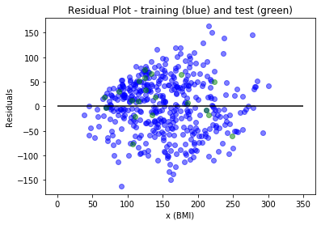

```python
## Re-Run code above with the best features.
## Collects more information about model performance.

# Create array with just the features in the feature index.
df_sub_features = df_features.iloc[:, best_features_rmse] # Use best features this time.

# Split the data into training/testing sets
diabetes_X_train = df_sub_features[:-20]
diabetes_X_test = df_sub_features[-20:]

# Create linear regression object
lm = linear_model.LinearRegression()

# Train the model using the training sets
fit = lm.fit(diabetes_X_train, diabetes_y_train)

# Make predictions using the testing set
diabetes_y_pred = fit.predict(diabetes_X_test)

# The coefficients
print('Coefficients: \n', fit.coef_)
print ( type(fit.coef_))

# https://bigdata-madesimple.com/how-to-run-linear-regression-in-python-scikit-learn/
# get feature names
colnames = np.asarray(df.columns)

# https://pandas.pydata.org/pandas-docs/stable/user_guide/merging.html
df_col = pd.DataFrame( data = np.asarray(best_features_rmse)  )
df_coef = pd.DataFrame( data = fit.coef_)
df_tbl =  pd.concat ( [df_col, df_coef] , axis = 1 )
df_tbl.columns = ['Columns', 'Coefficients']
print(df_tbl)
print(pd.DataFrame(data=np.asarray(df_features.columns)))

#  scipy.stats OLS linear regression model
X_train = sm.add_constant(diabetes_X_train)
lm2 = sm.OLS(diabetes_y_train, X_train).fit()
lm2.summary()

rmse = np.sqrt( mean_squared_error(diabetes_y_test, diabetes_y_pred))
r = r2_score(diabetes_y_test, diabetes_y_pred)

lm2.summary()

# The mean squared error
print("Mean squared error: %.2f"
      % mean_squared_error(diabetes_y_test, diabetes_y_pred))

print("Root mean squared error: %.2f"
      % np.sqrt( mean_squared_error(diabetes_y_test, diabetes_y_pred)) )

print("\nMean of diabetes target variable = ",diabetes_y_test.mean())

print("RMSE percentage of diabetes mean = ", \
      100 * np.sqrt( mean_squared_error(diabetes_y_test, diabetes_y_pred))/diabetes_y_test.mean())

print('Coefficient of determination: %.2f'
      % r2_score(diabetes_y_test, diabetes_y_pred))

# c = color
# alpha - blending value, between 0 (transparent) and 1 (opaque)
plt.scatter( lm.predict(diabetes_X_train), lm.predict(diabetes_X_train) - diabetes_y_train, c = 'b', alpha = '0.5')
plt.scatter( lm.predict(diabetes_X_test), lm.predict(diabetes_X_test) - diabetes_y_test, c = 'g', alpha = '0.5')
plt.hlines(y = 0, xmin = 0, xmax = 350)
plt.title('Residual Plot - training (blue) and test (green)')
plt.ylabel('Residuals')
plt.xlabel('x (BMI)')
```

### Selected Features

The following four features were selected due to random sampling:

- sex
- s5
- s1
- bmi

#### Accuracy:

- MSE: 1840.02
- RMSE: 42.90

The closer these numbers are to 0, the better - sum of all errors should be small. We want our sum of residuals to be 0. The Residual Plot shows that it is not. In fact the Residual Plot shows that there are a bunch of problems and errors made with out model.

Although there are errors within this model, this model performs better than the Multiple Linear Regression model that was built using all of the features.

- r squared: 0.62

r squared tells us how much variance is explained by our model (1 is perfect, 0 is the worst). Our value of 0.62 shows that we are getting to some sort of correlation. However, we still need to improve. Note: This is better than the Multiple Linear Regression model that was built using all features.

#### Accept or Reject?

Although this model has found some correlation between these features and Disease Progression Value, we didn't implement any feature engineering. We should **reject** this model because we can very likely do better, if we engineer some new features. Although we should **accept** this model based on the **current features** that we currently have due to the random sampling of features.

## Conclusions

Three models were built, and the Alternative Multiple Linear Regression performed the best. The main change was implementing "Randomized Feature Selection".

### Model Recap

#### Single Linear Regression

**rmse: 50.48**

This model used **bmi** as an input variable to predict the Disease Progression Rate. With a Root Mean Squared Error of 50.48, this model performed the worst of the three models built. This model didn't perform well because we excluded some useful pieces of information that this model would find useful.

#### Multiple Linear Regression

**rmse: 44.77**

This model used **All Features** as input variables to predict the Disease Progression Rate. With a Root Mean Squared Error of 44.77, this model performed better than model 1, but worse than model 3. This model performed better than model 1 because it takes more features into account. However, this model performed worst than model 3 because of **colinearity** and **noise**. Some features are highly correlated with others (such as s1 and s2). Other features gave noise to the data set - these features were random, and provided little insight into predicting the response variable.

#### Mulitple Linear Regression (Alternative)

**rmse: 42.90**

This was done by implementing **Randomized Feature Selection**. This randomly samples features uses them to build a model. The model performance is calculated using RMSE, and then best set of randomly sampled features is recorded and used as our final features.

This was implemented because we need to find the combination of features that best describe the data. This may also be achieved by trying every combination of features, but I wanted to test this method out because sometimes that process would take too long. Random sampling can significantly reduce the time need to test samples, while still ensuring a good amount of selected features.

Further, in class, you discussed trying **Forward/Backward Selection**, but this ignores the fact that some variables may not be significant without the presence of other variables. The solution to this is Randomized Feature Selection.

### What I learned

I learned more about the feature selection process, and different methods that can be utilized such as, forward selection, backward selection, and randomized sampling.

### Questions / Further Work

1. How can I change the coefficents of the variables to be squared (or inverse squared). I wanted to try this with the feature, **s3**, but I wasn't able to get it working properly.
2. The alternative model only implemented feature selection. I would like to do feature engineering as well, but I'm not sure where to start. What kind of features could I create that would give extra information to the model (that isn't already explained by the existing features)?